# Plotting lmer/glmer using the effects package

Dan Villarreal

22 May 2019

```r
knitr::opts_chunk$set(comment=NA)
```

# 1 Introduction

The [`effects` package](https://cran.r-project.org/package=effects) includes tools for constructing and plotting fixed effects of a large variety of models, including mixed-effects linear regression models (generated by `lmer()` from the `lme4` package) and logistic regression models (`glmer()`). I find that visualizing effects is a *much* better and easier way to understand a model than squinting at a summary table, especially when interactions are involved.

In this short guide, we’ll walk through how to use the `effects` package (including how to deal with some finicky features of `effects`):

1. How to run your model so `effects` won’t complain
2. How to construct an effects dataframe
3. How to plot effects in `ggplot2`

To demonstrate these functions, we’ll use some data from Lynn’s and my research on [vowel priming in QuakeBox](https://www.academia.edu/36925969/), which asked whether there was evidence of priming in phonetic variation across the NZE short front vowel shift. The `PrimingVowels.Rds` file in the same folder as this RMarkdown file contains data that we can use to re-create a version of our final model. Let’s read this data into our R environment:

```r
primingVowels <- readRDS("PrimingVowels.Rds")
```

Briefly, here’s what’s in this data: information on speakers (including social characteristics), words, two “Shift Index” columns that store the degree of shiftedness of the target and prime, the target and prime vowel categories, target and prime durations, the time difference between prime and target, and whether or not prime and target are different instances of the same word.

```r
summary(primingVowels)
```

```
       Speaker      Gender     AgeGroup          Word
 Speaker18 : 1700   F:41841   36-45:14533   that   : 4000
 Speaker118: 1465   M:16355   46-55:20710   and    : 3936
 Speaker58 : 1319             56-65:14532   in     : 3537
 Speaker125: 1191             66+  : 8421   it     : 3149
 Speaker117: 1085                           at     : 1041
 Speaker48 : 1014                           with   : 1024
 (Other)   :50422                           (Other):41509
 TargetShiftIndex   PrimeShiftIndex       Target        Prime
 Min.   :-3.98275   Min.   :-3.982752   TRAP :16154   TRAP :17764
 1st Qu.:-0.60465   1st Qu.:-0.624795   DRESS:14210   DRESS:12552
 Median : 0.09418   Median : 0.067789   KIT  :27832   KIT  :27880
 Mean   : 0.02573   Mean   : 0.004545
 3rd Qu.: 0.70827   3rd Qu.: 0.684466
 Max.   : 3.69441   Max.   : 3.694405

 TargetVowelDur    PrimeVowelDur     PrimeTargetTimeDiff
 Min.   :0.03000   Min.   :0.03000   Min.   :0.020
 1st Qu.:0.04000   1st Qu.:0.04000   1st Qu.:0.330
 Median :0.06000   Median :0.06000   Median :0.800
 Mean   :0.07668   Mean   :0.07578   Mean   :1.235
 3rd Qu.:0.09000   3rd Qu.:0.09000   3rd Qu.:1.700
 Max.   :1.59000   Max.   :1.59000   Max.   :9.995

 PrimeTargetSameWord
 Mode :logical
 FALSE:56043
 TRUE :2153
```

Let’s also load some packages: `tidyverse`, a suite of packages that makes R code faster, more readable, and safer; `lmerTest`, which imports `lme4` and adds *p*-values to `lmer()` summaries; and the `effects` package itself.

```r
pkgTest <- function(x) {
  if (!require(x, character.only=TRUE)) {
    install.packages(x)
    if (!require(x, character.only=TRUE)) stop(paste("Package", x, "not found"))
  }
}
pkgTest("tidyverse")
pkgTest("lmerTest")
pkgTest("effects")
```

```
lattice theme set by effectsTheme()
See ?effectsTheme for details.
```

# 2 How to run your model

`effects` is a little finicky in its requirements for the formatting of the models it runs. In particular:

- `effects` only accepts numeric and factor predictors in fixed effects; if any fixed effects aren’t numeric or factor, it throws an error and won’t proceed. This would be a problem for our `PrimeTargetSameWord` predictor, which has the type “logical”.
- For boring internal reasons, it fails when models are run using data that’s piped into `(g)lmer()`, rather than spelled out in the `data` argument to `(g)lmer()`.

Fortunately, both of these requirements are easy to deal with. To satisfy the first requirement, we’ll use the `mutate_if()` function from `dplyr` (part of `tidyverse`) to turn any character columns into factor columns, and any logical columns into factor columns. Here’s what that looks like:

```r
primingVowels %>%
  mutate_if(is.character, factor) %>%
  mutate_if(is.logical, factor)
```

| Speaker | Gender | AgeGroup | Word | TargetShiftIndex | PrimeShiftIndex | Target | Prime | TargetVowelDur | PrimeVowelDur | PrimeTargetTimeDiff | PrimeTargetSameWord |
| --- | --- | --- | --- | --- | --- | --- | --- | --- | --- | --- | --- |
| Speaker1 | M | 46-55 | meant | -0.4256904865 | -1.0184802469 | DRESS | DRESS | 0.07 | 0.08 | 0.590 | FALSE |
| Speaker1 | M | 46-55 | building | 0.6458409469 | -0.8000747539 | KIT | TRAP | 0.05 | 0.21 | 2.310 | FALSE |
| Speaker1 | M | 46-55 | and | 0.1872559352 | -0.0368034911 | TRAP | KIT | 0.16 | 0.06 | 0.200 | FALSE |
| Speaker1 | M | 46-55 | in | 0.1399565844 | 0.1872559352 | KIT | TRAP | 0.05 | 0.16 | 0.480 | FALSE |
| Speaker1 | M | 46-55 | and | -0.6178217606 | 1.3092907660 | TRAP | KIT | 0.19 | 0.03 | 1.890 | FALSE |
| Speaker1 | M | 46-55 | meeting | -0.6306624255 | -0.6178217606 | KIT | TRAP | 0.05 | 0.19 | 2.090 | FALSE |
| Speaker1 | M | 46-55 | and | -0.4407320775 | -0.6306624255 | TRAP | KIT | 0.25 | 0.05 | 2.610 | FALSE |
| Speaker1 | M | 46-55 | said | -0.6351305172 | -0.4407320775 | DRESS | TRAP | 0.16 | 0.25 | 1.460 | FALSE |
| Speaker1 | M | 46-55 | terribly | -1.2934067145 | -0.6351305172 | DRESS | DRESS | 0.05 | 0.16 | 1.000 | FALSE |
| Speaker1 | M | 46-55 | and | -0.3948966226 | 0.0007793949 | TRAP | KIT | 0.20 | 0.06 | 1.340 | FALSE |

[output cut: 9990 more lines]

To satisfy the second requirement, we specify the data in the `data` argument of `(g)lmer()`. So rather than using syntax like the following:

```
Some-data %>%
  lmer(Some-formula, data=.)
```

We’ll use syntax like the following:

```
lmer(Some-formula, data=Some-data)
```

(The first version might look ugly and unnecessary if our data are simple, but if we’re doing a bunch of manipulations to our data in a long pipe chain, it’s a lot clearer to have that pipe chain outside the `(g)lmer()` call rather than within it.)

Let’s put this together and run our `lmer()` model. Our actual model was more complicated than this one, but we’ll use a somewhat pared-down version to keep things simpler (for that reason, some of the plots will look different from what we’ve presented in the past). This model took about 90 seconds to run on my laptop:

```r
primingMod <-
  lmer(TargetShiftIndex ~ PrimeShiftIndex * Target * Prime *
         (log(PrimeTargetTimeDiff) + log(TargetVowelDur) + log(PrimeVowelDur) + AgeGroup + Gender) +
         PrimeShiftIndex * Target * PrimeTargetSameWord +
         (1 | Speaker) + (1 | Word),
       data=primingVowels %>%
         mutate_if(is.character, factor) %>%
         mutate_if(is.logical, factor),
       REML=FALSE)
```

Let’s take a look at the model summary:

```r
primingMod %>% summary()
```

```
Linear mixed model fit by maximum likelihood . t-tests use
  Satterthwaite's method [lmerModLmerTest]
Formula:
TargetShiftIndex ~ PrimeShiftIndex * Target * Prime * (log(PrimeTargetTimeDiff) +
    log(TargetVowelDur) + log(PrimeVowelDur) + AgeGroup + Gender) +
    PrimeShiftIndex * Target * PrimeTargetSameWord + (1 | Speaker) +
    (1 | Word)
   Data:
primingVowels %>% mutate_if(is.character, factor) %>% mutate_if(is.logical,
    factor)

     AIC      BIC   logLik deviance df.resid
136365.0 137737.7 -68029.5 136059.0    58043

Scaled residuals:
    Min      1Q  Median      3Q     Max
-6.0375 -0.5534  0.0319  0.5993  4.8375

Random effects:
 Groups   Name        Variance Std.Dev.
 Word     (Intercept) 0.34864  0.5905
 Speaker  (Intercept) 0.04455  0.2111
 Residual             0.55909  0.7477
Number of obs: 58196, groups:  Word, 3883; Speaker, 146

Fixed effects:
                                                                  Estimate
(Intercept)                                                      1.108e+00
PrimeShiftIndex                                                  3.040e-01
TargetDRESS                                                      5.641e-01
TargetKIT                                                       -1.375e+00
PrimeDRESS                                                      -5.075e-02
PrimeKIT                                                         7.111e-02
log(PrimeTargetTimeDiff)                                        -1.769e-02
log(TargetVowelDur)                                              4.765e-01
log(PrimeVowelDur)                                              -1.349e-01
AgeGroup46-55                                                   -3.597e-02
AgeGroup56-65                                                   -8.962e-02
AgeGroup66+                                                     -1.707e-01
GenderM                                                         -2.459e-01
```

[output cut: 879 more lines]

```
PrimeShiftIndex:TargetKIT:PrimeKIT:AgeGroup46-55                ***
PrimeShiftIndex:TargetDRESS:PrimeDRESS:AgeGroup56-65
PrimeShiftIndex:TargetKIT:PrimeDRESS:AgeGroup56-65              .
PrimeShiftIndex:TargetDRESS:PrimeKIT:AgeGroup56-65
PrimeShiftIndex:TargetKIT:PrimeKIT:AgeGroup56-65                **
PrimeShiftIndex:TargetDRESS:PrimeDRESS:AgeGroup66+
PrimeShiftIndex:TargetKIT:PrimeDRESS:AgeGroup66+
PrimeShiftIndex:TargetDRESS:PrimeKIT:AgeGroup66+
PrimeShiftIndex:TargetKIT:PrimeKIT:AgeGroup66+                  *
PrimeShiftIndex:TargetDRESS:PrimeDRESS:GenderM
PrimeShiftIndex:TargetKIT:PrimeDRESS:GenderM
PrimeShiftIndex:TargetDRESS:PrimeKIT:GenderM
PrimeShiftIndex:TargetKIT:PrimeKIT:GenderM                      **
---
Signif. codes:  0 '***' 0.001 '**' 0.01 '*' 0.05 '.' 0.1 ' ' 1
```

```
Correlation matrix not shown by default, as p = 150 > 12.
Use print(x, correlation=TRUE)  or
    vcov(x)        if you need it
```

# 3 How to construct an effects dataframe

Now that we’ve got our model, we’ll do two things to it: construct fitted model effects, and plot these effects. Both of these can be accomplished via functions in `effects`, but I prefer to take the fitted model effects constructed by `effects` and use the flexible and powerful plotting capabilities of `ggplot2` instead.

This is pretty straightforward: we pipe the model to the function `Effect()`, make a data frame out of that, and then we’ve got something that works nicely with `ggplot2`. (FYI, the `effects` package provides a few functions for constructing effects, differing only in their argument syntax; I find `Effect()`’s argument syntax easiest to deal with, but your mileage may vary.)

So if we want to plot a main effect of `PrimeShiftIndex`, we pipe our priming model to `Effect()`, then pipe that to `as.data.frame()`. The result is a data frame of fitted effects; at different values of `PrimeShiftIndex`, `fit` is the fitted mean of the dependent variable (here, `TargetShiftIndex`), `se` is the standard error of the fit, and `lower`/`upper` are the bounds of the 95% confidence interval (FYI, you can adjust the confidence level via the `se` argument to `Effect()`).

```r
primingMod %>%
  Effect(c("PrimeShiftIndex"), .) %>%
  as.data.frame()
```

|  | PrimeShiftIndex | fit | se | lower | upper |
| --- | --- | --- | --- | --- | --- |
| 1 | -4.0 | -0.04670748 | 0.03131548 | -0.10808598 | 0.01467102 |
| 2 | -2.0 | -0.03754032 | 0.02476142 | -0.08607283 | 0.01099218 |
| 3 | -0.1 | -0.02883152 | 0.02223345 | -0.07240919 | 0.01474615 |
| 4 | 2.0 | -0.01920600 | 0.02498296 | -0.06817273 | 0.02976072 |
| 5 | 4.0 | -0.01003884 | 0.03166544 | -0.07210327 | 0.05202558 |

If we want to plot an interaction effect, we simply pass a vector of multiple predictors to the first argument of `Effect()`, like so. The following dataframe has fitted effects at different values of `PrimeShiftIndex`, `Target`, and `PrimeTargetSameWord`:

```r
primingMod %>%
  Effect(c("PrimeShiftIndex", "Target", "PrimeTargetSameWord"), .) %>%
  as.data.frame()
```

|  | PrimeShiftIndex | Target | PrimeTargetSameWord | fit | se | lower | upper |
| --- | --- | --- | --- | --- | --- | --- | --- |
| 1 | -4.0 | TRAP | FALSE | -0.08464007 | 0.04961419 | -0.181884121 | 0.01260398 |
| 2 | -2.0 | TRAP | FALSE | -0.03542923 | 0.03701453 | -0.107977891 | 0.03711944 |
| 3 | -0.1 | TRAP | FALSE | 0.01132108 | 0.03178991 | -0.050987303 | 0.07362946 |
| 4 | 2.0 | TRAP | FALSE | 0.06299246 | 0.03716490 | -0.009850923 | 0.13583585 |
| 5 | 4.0 | TRAP | FALSE | 0.11220331 | 0.04983850 | 0.014519607 | 0.20988701 |
| 6 | -4.0 | DRESS | FALSE | 0.06155149 | 0.05027470 | -0.036987173 | 0.16009016 |
| 7 | -2.0 | DRESS | FALSE | 0.09276943 | 0.03607851 | 0.022055374 | 0.16348348 |
| 8 | -0.1 | DRESS | FALSE | 0.12242647 | 0.03013413 | 0.063363433 | 0.18148951 |
| 9 | 2.0 | DRESS | FALSE | 0.15520530 | 0.03670217 | 0.083268881 | 0.22714173 |
| 10 | 4.0 | DRESS | FALSE | 0.18642324 | 0.05116958 | 0.086130613 | 0.28671587 |

[output cut: 20 more lines]

One minor wrinkle is that `effects`’s function for turning the output of `Effect()` into a data frame doesn’t respect the ordering of factor levels, instead rearranging factor levels alphabetically. (I find this a bit bizarre given that `effects` forces you to use factors rather than character predictors.) This is evident if you look at the summary of the dataframe we just created; note that the levels of `Target` have been re-arranged to DRESS, then KIT, then TRAP:

```r
primingMod %>%
  Effect(c("PrimeShiftIndex", "Target", "PrimeTargetSameWord"), .) %>%
  as.data.frame() %>%
  summary()
```

```
 PrimeShiftIndex   Target   PrimeTargetSameWord      fit
 Min.   :-4.00   DRESS:10   FALSE:15            Min.   :-0.493158
 1st Qu.:-2.00   KIT  :10   TRUE :15            1st Qu.:-0.167232
 Median :-0.10   TRAP :10   NA   : 0            Median :-0.035077
 Mean   :-0.02   NA   : 0                       Mean   :-0.009928
 3rd Qu.: 2.00                                  3rd Qu.: 0.121341
 Max.   : 4.00                                  Max.   : 0.806345
       se              lower              upper
 Min.   :0.02650   Min.   :-0.82764   Min.   :-0.28104
 1st Qu.:0.03678   1st Qu.:-0.25689   1st Qu.:-0.07782
 Median :0.05006   Median :-0.12000   Median : 0.05800
 Mean   :0.06814   Mean   :-0.14349   Mean   : 0.12363
 3rd Qu.:0.09421   3rd Qu.: 0.02017   3rd Qu.: 0.22283
 Max.   :0.17819   Max.   : 0.45709   Max.   : 1.15560
```

We probably wanted our original factor levels in the order they were in for a reason—in this case, the original factor level order reflected the historical order of changes in NZE short front shift—and we’ll want our plots to reflect this order, as well. To fix this behavior, I’ve created a new function, `df.eff()`, that tweaks the code for `effects:::as.data.frame.eff()` to respect the original ordering of factor levels:

```r
df.eff <- function (x, row.names = NULL, optional = TRUE, transform = x$transformation$inverse,
  ...) {
  if (class(x)!="eff") stop("x must be of class eff")
  xx <- x$x
  for (var in names(xx)) {
    if (is.factor(xx[[var]])) {
      ##Fix the issue where levels(xx[[var]]!=(unique(xx[[var]])==levels(origDF[[var]])))
      xx[[var]] <- addNA(factor(xx[[var]], levels=unique(xx[[var]])))
    }
  }
  x$x <- xx
  result <- if (is.null(x$se))
    data.frame(x$x, fit = transform(x$fit))
  else data.frame(x$x, fit = transform(x$fit), se = x$se,
    lower = transform(x$lower), upper = transform(x$upper))
  attr(result, "transformation") <- transform
  result
}
```

As you can see, `df.eff()` preserves the original order of `Target`:

```r
primingMod %>%
  Effect(c("PrimeShiftIndex", "Target", "PrimeTargetSameWord"), .) %>%
  df.eff() %>%
  summary()
```

```
 PrimeShiftIndex   Target   PrimeTargetSameWord      fit
 Min.   :-4.00   TRAP :10   FALSE:15            Min.   :-0.493158
 1st Qu.:-2.00   DRESS:10   TRUE :15            1st Qu.:-0.167232
 Median :-0.10   KIT  :10   NA   : 0            Median :-0.035077
 Mean   :-0.02   NA   : 0                       Mean   :-0.009928
 3rd Qu.: 2.00                                  3rd Qu.: 0.121341
 Max.   : 4.00                                  Max.   : 0.806345
       se              lower              upper
 Min.   :0.02650   Min.   :-0.82764   Min.   :-0.28104
 1st Qu.:0.03678   1st Qu.:-0.25689   1st Qu.:-0.07782
 Median :0.05006   Median :-0.12000   Median : 0.05800
 Mean   :0.06814   Mean   :-0.14349   Mean   : 0.12363
 3rd Qu.:0.09421   3rd Qu.: 0.02017   3rd Qu.: 0.22283
 Max.   :0.17819   Max.   : 0.45709   Max.   : 1.15560
```

Now we’ve got something that can be passed to `ggplot2`.

# 4 How to plot effects in `ggplot2`

If you know how to use `ggplot2`, it’s straightforward to turn these dataframes into nice ggplots—and if you don’t know how to use `ggplot2`, there are [heaps](https://r4ds.had.co.nz/data-visualisation.html) of [great](https://jofrhwld.github.io/avml2012/) [resources](http://joeystanley.com/blog/making-vowel-plots-in-r-part-1) out there.

Recall that `ggplot2` is all about mapping columns in your dataframe to *aesthetics* of your plot. So what should we map to what? First, `fit` is the fitted mean for that combination of factor levels and/or numeric values, so we’ll map it to the `y` aesthetic (for `geom_line()`, `geom_point()`, etc.). Since `lower` and `upper` are 95% confidence interval bounds, we’ll map these to the `ymin` and `ymax` aesthetics (for `geom_errorbar()`, `geom_ribbon()`, etc.). And depending on the predictors and whether or not you’ve got main effects or interaction effects, you might want to map some predictors to the `x` aesthetic, others to the `group` aesthetic, and others still as faceting variables.

## 4.1 Main effect, continuous predictor

Let’s apply these to the simple case of the main effect of `PrimeShiftIndex`, a continuous predictor. Here’s what that looks like if we just plot a line of the fitted means:

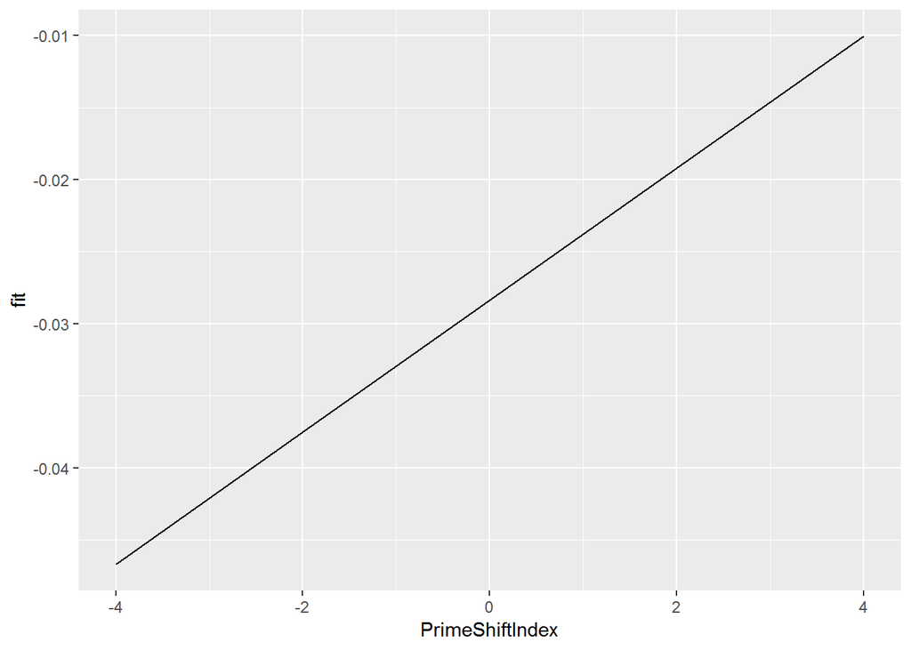

```r
primingMod %>%
  Effect(c("PrimeShiftIndex"), .) %>%
  df.eff() %>%
  ggplot(aes(x=PrimeShiftIndex, y=fit)) +
  geom_line()
```

Okay, that’s a start, but we can do better. Just to name two changes, “fit” isn’t a very informative y-axis title, and the y-axis limits are overfit to our line. Fortunately, since we’re using `ggplot2`, we can use the same functions for this plot as we would for any other ggplot.

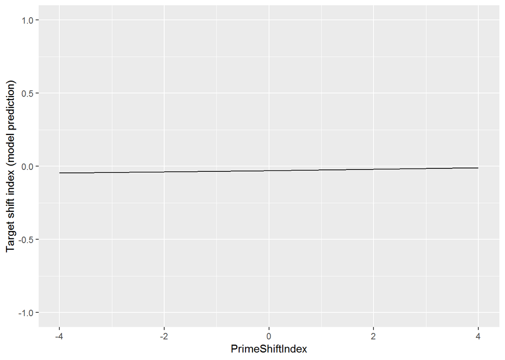

```r
ylabel <- "Target shift index (model prediction)"
ylim1 <- c(-1, 1)
primingMod %>%
  Effect(c("PrimeShiftIndex"), .) %>%
  df.eff() %>%
  ggplot(aes(x=PrimeShiftIndex, y=fit)) +
  geom_line() +
  scale_y_continuous(ylabel, limits=ylim1)
```

Now, if we try to add confidence bands with `geom_ribbon()`, we find some issues with the default settings:

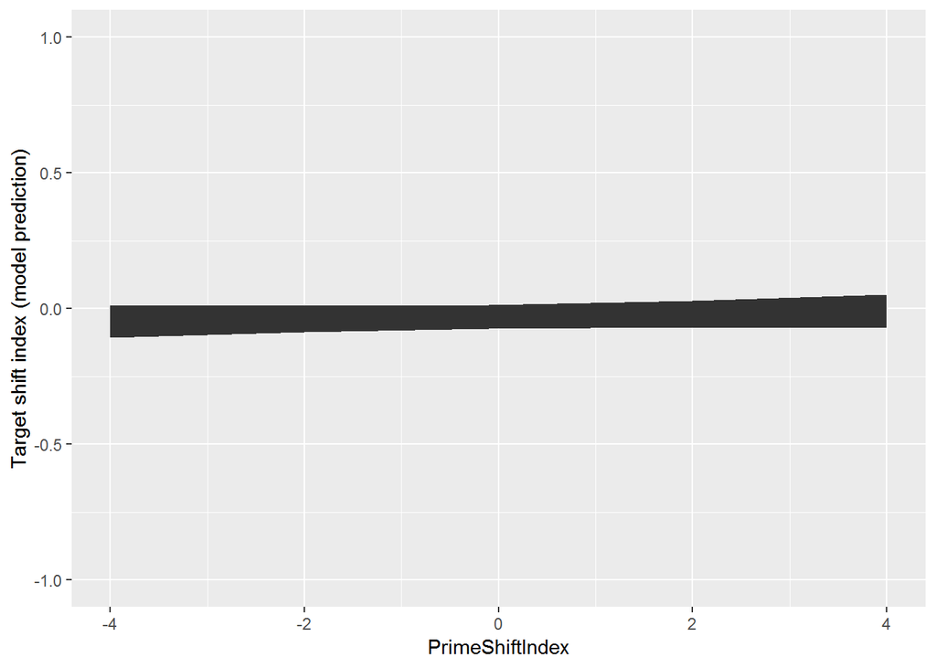

```r
primingMod %>%
  Effect(c("PrimeShiftIndex"), .) %>%
  df.eff() %>%
  ggplot(aes(x=PrimeShiftIndex, y=fit, ymin=lower, ymax=upper)) +
  geom_line() +
  geom_ribbon() +
  scale_y_continuous(ylabel, limits=ylim1)
```

The ribbon defaults to the same color and shade as the line, so we can’t tell the line from the ribbon! To deal with this, let’s pass some nice color and shading values to the line and ribbon:

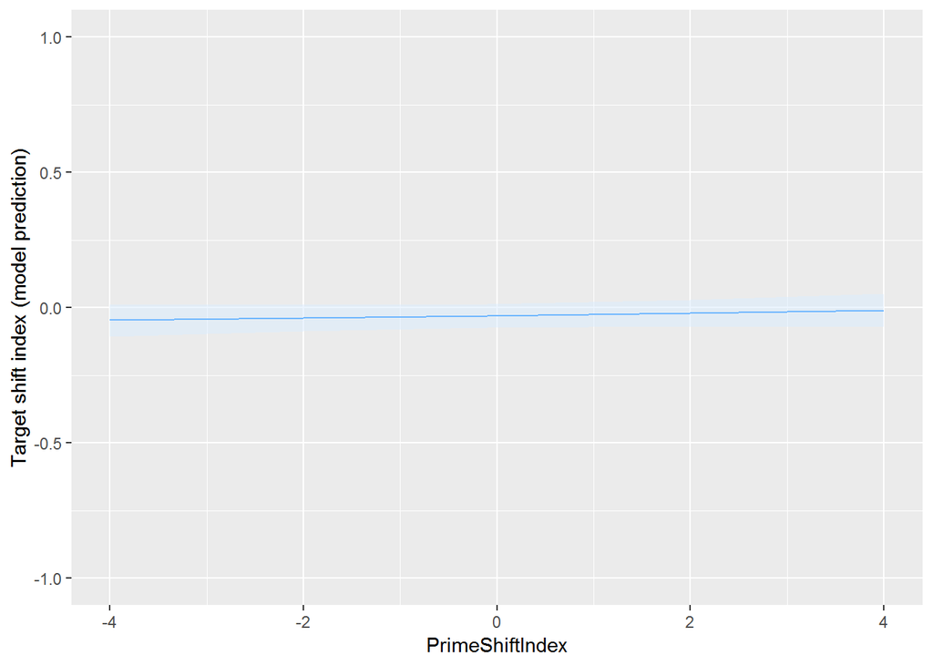

```r
lineCol <- rgb(0, 128, 255, maxColorValue=255)
ribbonFill <- rgb(217, 236, 255, maxColorValue=255)
ribbonAlpha <- 0.5
primingMod %>%
  Effect(c("PrimeShiftIndex"), .) %>%
  df.eff() %>%
  ggplot(aes(x=PrimeShiftIndex, y=fit, ymin=lower, ymax=upper)) +
  geom_line(color=lineCol) +
  geom_ribbon(fill=ribbonFill, alpha=ribbonAlpha) +
  scale_y_continuous(ylabel, limits=ylim1)
```

That’s much better! Note that `ggplot2` will draw geoms in the order that you call them; in the previous plot, the ribbon covers up the line a bit, but if we call the ribbon first and then the line, the line stands out better:

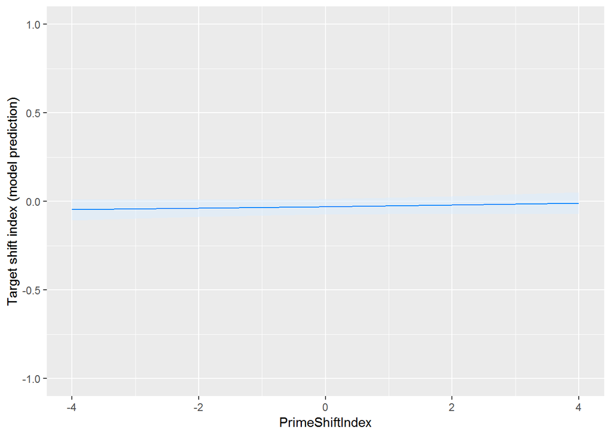

```r
primingMod %>%
  Effect(c("PrimeShiftIndex"), .) %>%
  df.eff() %>%
  ggplot(aes(x=PrimeShiftIndex, y=fit, ymin=lower, ymax=upper)) +
  geom_ribbon(fill=ribbonFill, alpha=ribbonAlpha) +
  geom_line(color=lineCol) +
  scale_y_continuous(ylabel, limits=ylim1)
```

## 4.2 Main effect, factor predictor

Here’s another simple example: the main effect of `Gender`. Here, our `x` aesthetic is a factor rather than continuous, so instead of using `geom_line()` and `geom_ribbon()`, we’ll use `geom_point()` and `geom_errorbar()`. To maintain consistency, we’ll use the same y-axis title and limits as in the previous plot.

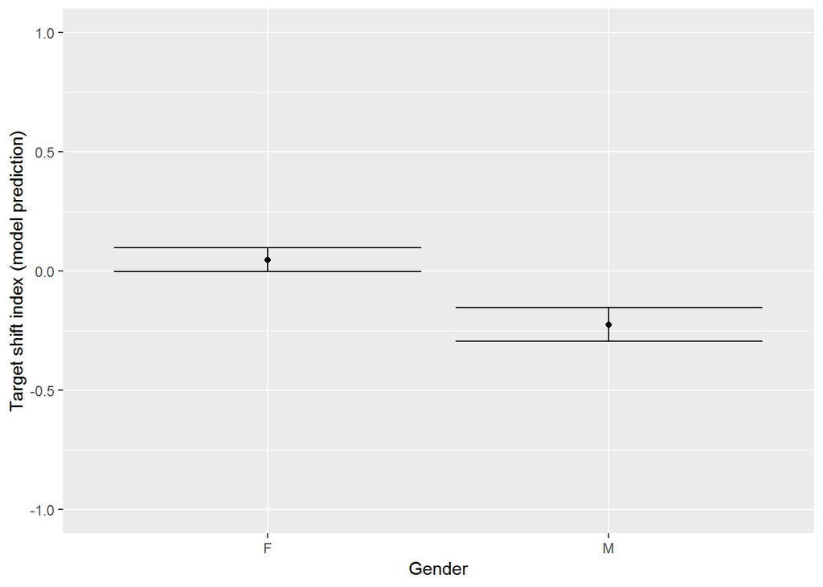

```r
primingMod %>%
  Effect(c("Gender"), .) %>%
  df.eff() %>%
  ggplot(aes(x=Gender, y=fit, ymin=lower, ymax=upper)) +
  geom_point() +
  geom_errorbar() +
  scale_y_continuous(ylabel, limits=ylim1)
```

## 4.3 Interactions

Let’s make things a little more complicated by considering a three-way interaction between `PrimeShiftIndex`, `Target`, and `PrimeTargetSameWord`. The challenge here is how to most clearly convey the combined effects of one numeric predictor (`PrimeShiftIndex`) and two factors (`Target` and `PrimeTargetSameWord`) on our dependent variable. The truth is, there’s not necessarily one right way to do it; what’s best for you will depend on your research questions, your results, and the effects you want to highlight.

In this case, since we are most interested in the effect of `PrimeShiftIndex`, I decided to consistenly map it to the `x` aesthetic in every plot where it was involved. Since our hypothesis was that `PrimeTargetSameWord` would mediate the effect of `PrimeShiftIndex`, it’s clearest to assess that by overlaying lines that differed only by `PrimeTargetSameWord`—in other words, mapping `PrimeTargetSameWord` to the `color` aesthetic. In plots where I had lines overlaid, I excluded the confidence ribbons to avoid busying the plot. And `Target`, as a factor, is a good candidate to be used as a faceting variable (i.e., defining sub-plots); in the call to `facet_grid()`, the formula `. ~ Target` means “don’t create row facets; create column facets on the variable `Target`”, and `labeller=label_both` means “create labels like ‘Target: TRAP’ as opposed to just ‘TRAP’”.

Here’s how that looks. The main takeaway from this plot is “across Target vowel categories, the repetition effect was stronger when prime and target were the same word”.

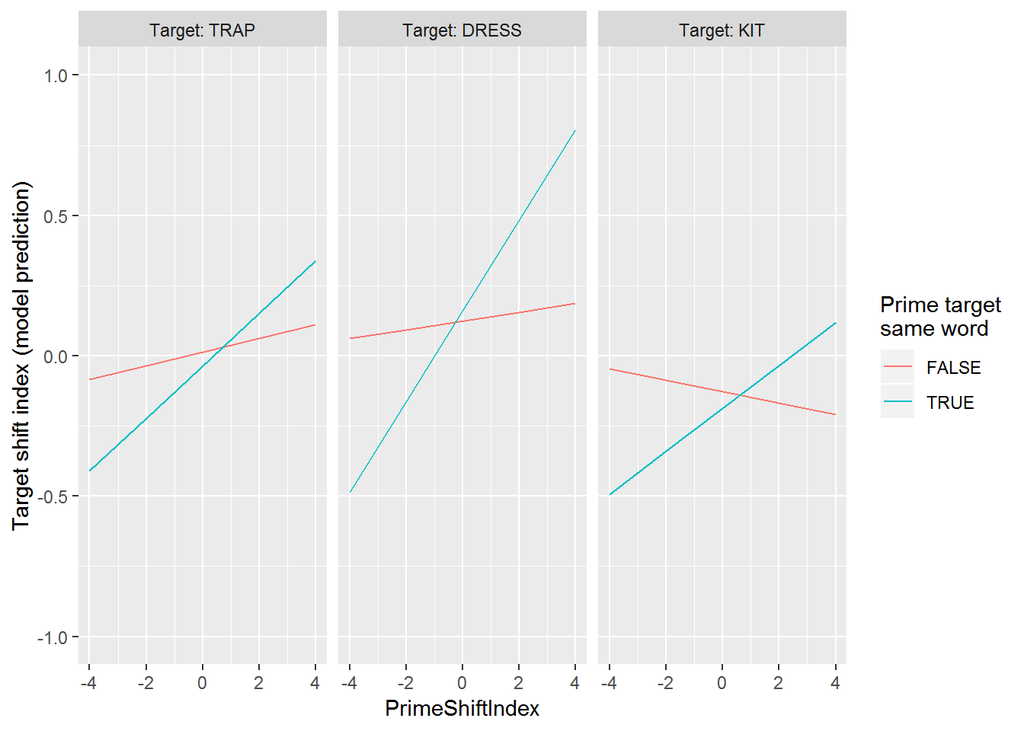

```r
primingMod %>%
  Effect(c("PrimeShiftIndex", "Target", "PrimeTargetSameWord"), .) %>%
  df.eff() %>%
  ggplot(aes(x=PrimeShiftIndex, y=fit, color=PrimeTargetSameWord)) +
  geom_line() +
  facet_grid(. ~ Target, labeller=label_both) +
  scale_y_continuous(ylabel, limits=ylim1) +
  scale_color_discrete("Prime target\nsame word")
```

Here’s another example with two factor predictors: `Gender` and `Target`. Since we’ve just used `Target` for faceting, we could do the same here and map `Gender` to `x`.

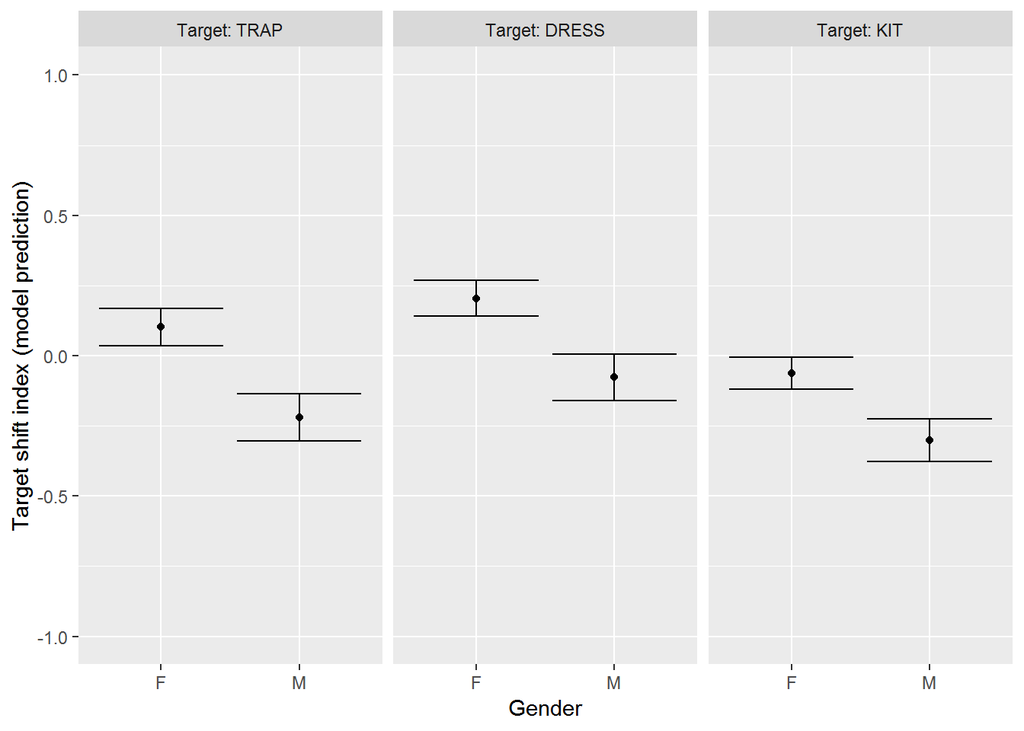

```r
primingMod %>%
  Effect(c("Gender", "Target"), .) %>%
  df.eff() %>%
  ggplot(aes(x=Gender, y=fit, ymin=lower, ymax=upper)) +
  geom_point() +
  geom_errorbar() +
  facet_grid(. ~ Target, labeller=label_both) +
  scale_y_continuous(ylabel, limits=ylim1)
```

But this plot hides the key insight that men lag women to a consistent degree with respect to the shifted vowels. To make this trend jump off the page better, I’ve mapped `Target` to the `x` aesthetic and `Gender` to `group` and `color`, adding a `geom_path()` to make the comparison between adjacent vowels more evident. Mapping `Gender` to `group` and `color` also pulls the points and errorbars more tightly together by `Gender`, emphasizing that `Gender`, not `Target`, is the salient comparison here:

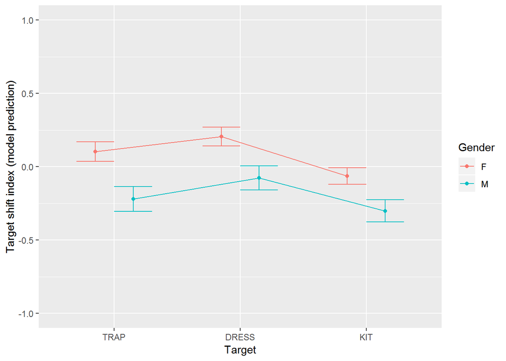

```r
primingMod %>%
  Effect(c("Gender", "Target"), .) %>%
  df.eff() %>%
  ggplot(aes(x=Target, y=fit, ymin=lower, ymax=upper, group=Gender, color=Gender)) +
  geom_point(position=position_dodge(width=0.6)) +
  geom_line(position=position_dodge(width=0.6)) +
  geom_errorbar(width=0.6, position="dodge") +
  scale_y_continuous(ylabel, limits=ylim1)
```

## 4.4 Adjusting `xlevels`

If you have continuous predictors modeled as nonlinear (e.g., via a log-transformation), they can show up as non-smooth line segments in the effects plot. This is because for each numeric predictor, by default `Effect()` samples “five values equally spaced over its range and then rounded to ‘nice’ numbers”; for non-linear predictors, sampling over five values makes for bumpy lines. This is evident in the plot of the interaction of `Target` and `log(TargetVowelDur)` below.

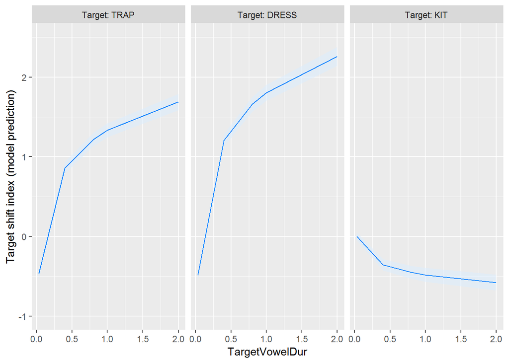

```r
primingMod %>%
  Effect(c("Target", "TargetVowelDur"), .) %>%
  df.eff() %>%
  ggplot(aes(x=TargetVowelDur, y=fit, ymin=lower, ymax=upper)) +
  geom_ribbon(fill=ribbonFill, alpha=ribbonAlpha) +
  geom_line(color=lineCol) +
  scale_y_continuous(ylabel, limits=c(-1, 2.5)) +
  facet_grid(. ~ Target, labeller=label_both)
```

To smooth out these lines, we can ratchet up the resolution of the `log(TargetVowelDur)` sampling. We do this by specifying the `xlevels` argument of `Effect()` as a list with one element, named `TargetVowelDur`, that represents an arbitrarily large number of sampling points. This results in much smoother lines:

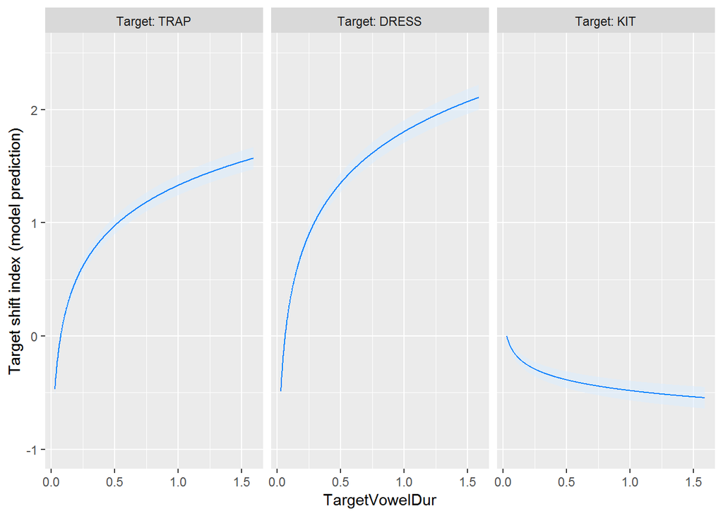

```r
primingMod %>%
  Effect(c("Target", "TargetVowelDur"), ., xlevels=list(TargetVowelDur=1000)) %>%
  df.eff() %>%
  ggplot(aes(x=TargetVowelDur, y=fit, ymin=lower, ymax=upper)) +
  geom_ribbon(fill=ribbonFill, alpha=ribbonAlpha) +
  geom_line(color=lineCol) +
  scale_y_continuous(ylabel, limits=c(-1, 2.5)) +
  facet_grid(. ~ Target, labeller=label_both)
```

Another spot where `xlevels` comes in handy is overriding the default ‘nice’ values that `Effect()` produces for continuous predictors, in particular when you want to treat these continuous predictors as quasi-factors (that is, showing how effects are different at different values of continuous predictors). As an example, let’s explore the interaction of `PrimeShiftIndex` and `PrimeTargetTimeDiff`, since our hypothesis is that `PrimeTargetTimeDiff` mediates the effect of `PrimeShiftIndex`, with longer differences between prime and target leading to less potent repetition effects. A few plots ago, we explored a similar example of `PrimeTargetSameWord` mediating the effect of `PrimeShiftIndex` by comparing slopes at different levels of `PrimeTargetSameWord` (mapping `PrimeTargetSameWord` to `color`), so we’ll look to do the same with `PrimeTargetTimeDiff`. Here’s what it looks like when we use the defaults (I’ve zoomed in some y values to make the differences between the next few plots clearer).

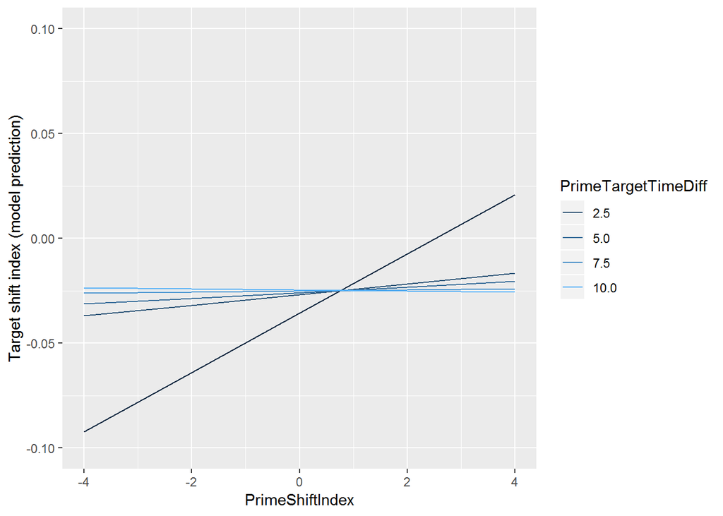

```r
primingMod %>%
  Effect(c("PrimeShiftIndex", "PrimeTargetTimeDiff"),
         .) %>%
  df.eff() %>%
  ggplot(aes(x=PrimeShiftIndex, y=fit, group=PrimeTargetTimeDiff, color=PrimeTargetTimeDiff)) +
  geom_line() +
  scale_y_continuous(ylabel, limits=c(-0.1, 0.1)) +
  scale_color_continuous(guide="legend")
```

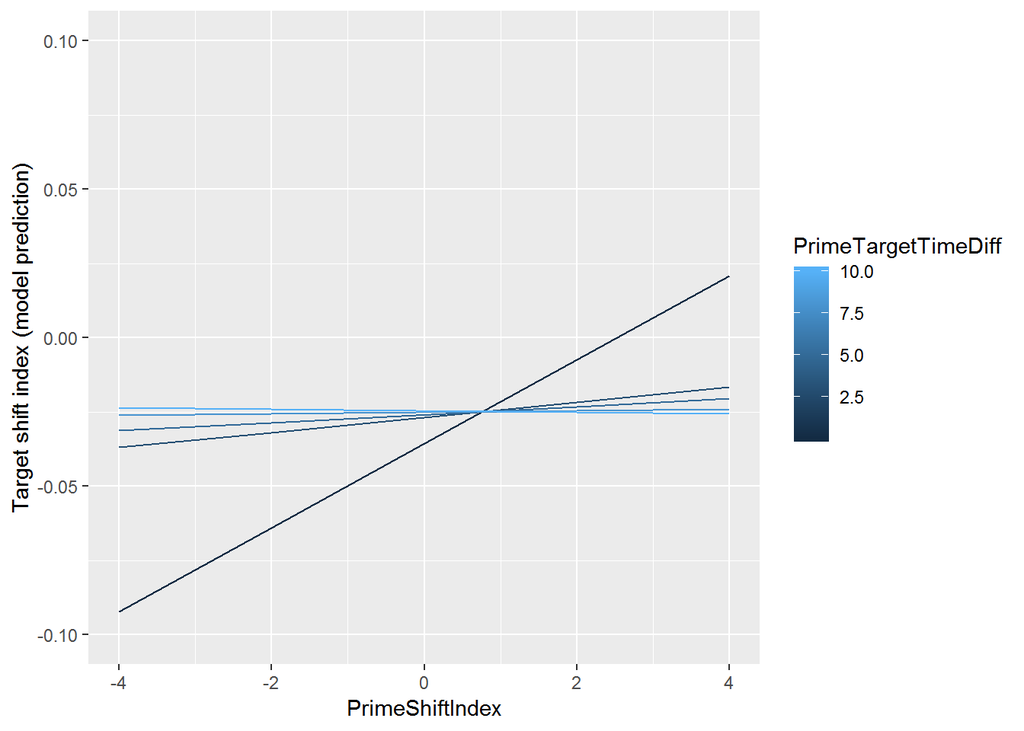

```r
primingMod %>%
  Effect(c("PrimeShiftIndex", "PrimeTargetTimeDiff"),
         .) %>%
  df.eff() %>%
  ggplot(aes(x=PrimeShiftIndex, y=fit, group=PrimeTargetTimeDiff, color=PrimeTargetTimeDiff)) +
  geom_line() +
  scale_y_continuous(ylabel, limits=c(-0.1, 0.1)) +
  scale_color_continuous(guide="colorbar")
```

```r
primingVowels$PrimeTargetTimeDiff %>% summary()
```

```
   Min. 1st Qu.  Median    Mean 3rd Qu.    Max.
  0.020   0.330   0.800   1.235   1.700   9.995
```

```r
mean(primingVowels$PrimeTargetTimeDiff < 2.5)
```

```
[1] 0.8643378
```

```r
mean(primingVowels$PrimeTargetTimeDiff < 5)
```

```
[1] 0.9776445
```

```r
mean(primingVowels$PrimeTargetTimeDiff < 7.5)
```

```
[1] 0.996065
```

In my opinion, the effects should sample `PrimeTargetTimeDiff` at values representative of its distribution, so the reader can get a better sense of the shape of the data. Here’s how we do that. First, pass the five-number summary of `PrimeTargetTimeDiff` to the `xlevels` argument of `Effect()`. As you can see below, this produces an effects dataframe where `PrimeTargetTimeDiff` is sampled at more appropriate values:

```r
primingMod %>%
  Effect(c("PrimeShiftIndex", "PrimeTargetTimeDiff"),
         .,
         xlevels=list(PrimeTargetTimeDiff = primingVowels$PrimeTargetTimeDiff %>% quantile(0:4/4))) %>%
  df.eff()
```

|  | PrimeShiftIndex | PrimeTargetTimeDiff | fit | se | lower | upper |
| --- | --- | --- | --- | --- | --- | --- |
| 1 | -4.0 | 0.020 | -0.092254312 | 0.05276481 | -0.19567359 | 0.011164967 |
| 2 | -2.0 | 0.020 | -0.063988878 | 0.03395725 | -0.13054525 | 0.002567493 |
| 3 | -0.1 | 0.020 | -0.037136715 | 0.02492111 | -0.08598222 | 0.011708786 |
| 4 | 2.0 | 0.020 | -0.007458009 | 0.03444424 | -0.07496888 | 0.060052863 |
| 5 | 4.0 | 0.020 | 0.020807425 | 0.05339238 | -0.08384190 | 0.125456755 |
| 6 | -4.0 | 0.330 | -0.061283965 | 0.03226267 | -0.12451896 | 0.001951034 |
| 7 | -2.0 | 0.330 | -0.046004729 | 0.02517263 | -0.09534321 | 0.003333752 |
| 8 | -0.1 | 0.330 | -0.031489456 | 0.02239895 | -0.07539151 | 0.012412596 |
| 9 | 2.0 | 0.330 | -0.015446258 | 0.02539373 | -0.06521808 | 0.034325568 |
| 10 | 4.0 | 0.330 | -0.000167023 | 0.03260736 | -0.06407761 | 0.063743562 |

[output cut: 15 more lines]

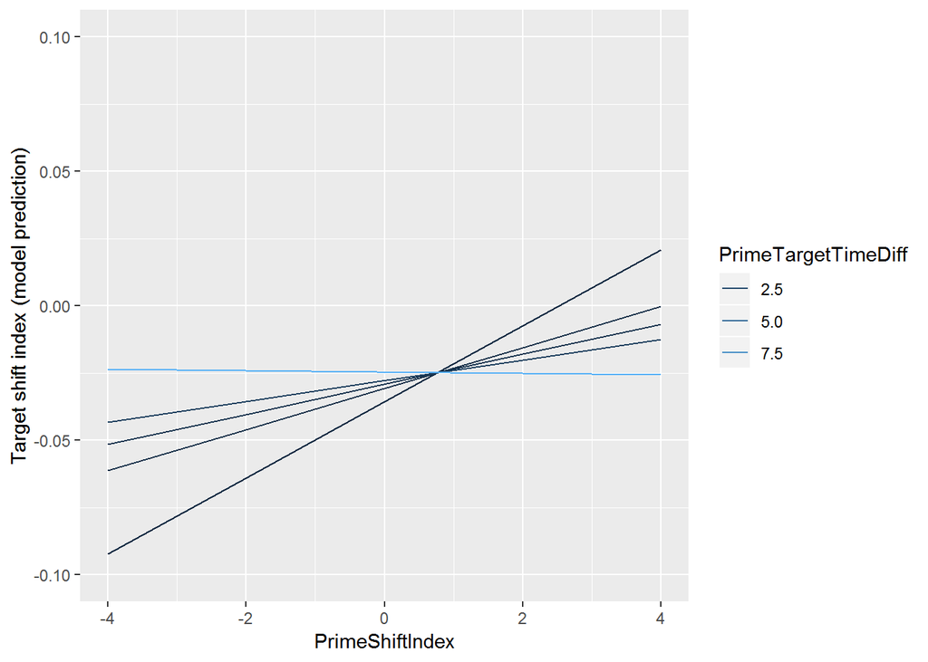

```r
primingMod %>%
  Effect(c("PrimeShiftIndex", "PrimeTargetTimeDiff"),
         .,
         xlevels=list(PrimeTargetTimeDiff = primingVowels$PrimeTargetTimeDiff %>% quantile(0:4/4))) %>%
  df.eff() %>%
  ggplot(aes(x=PrimeShiftIndex, y=fit, group=PrimeTargetTimeDiff, color=PrimeTargetTimeDiff)) +
  geom_line() +
  scale_y_continuous(ylabel, limits=c(-0.1, 0.1)) +
  scale_color_continuous(guide="legend")
```

To remedy that situation, here’s what we’ll do. First, get a vector of breaks for the legend by pulling the unique values out of the effects dataframe. (For some inscrutable reason, defining `brks` as `primingVowels$PrimeTargetTimeDiff %>% quantile(0:4/4) %>% unname()` leads to different results in the plot.)

```r
brks <-
  primingMod %>%
  Effect(c("PrimeShiftIndex", "PrimeTargetTimeDiff"),
         .,
         xlevels=list(PrimeTargetTimeDiff = primingVowels$PrimeTargetTimeDiff %>% quantile(0:4/4))) %>%
  df.eff() %>%
  pull(PrimeTargetTimeDiff) %>%
  unique() %>%
  sort()
brks
```

```
[1] 0.020 0.330 0.800 1.700 9.995
```

Then pass this vector of breaks to the `labels` and `breaks` arguments of `scale_color_continuous`.

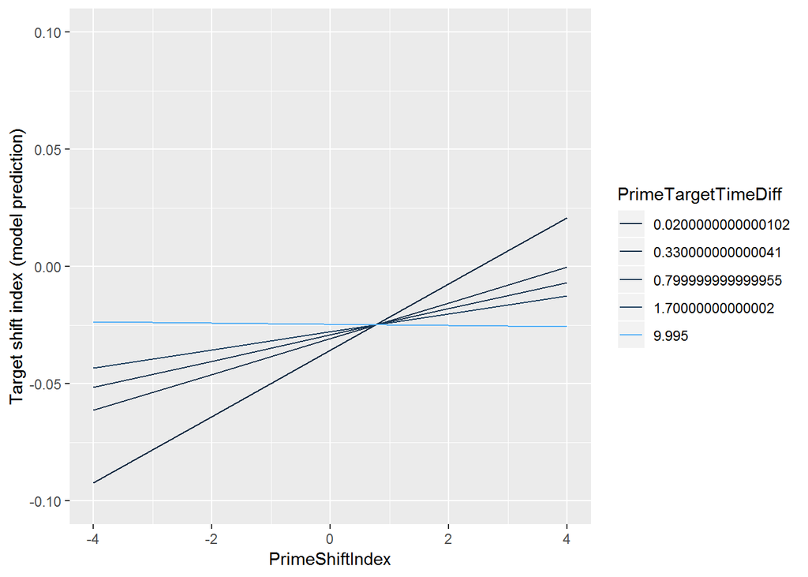

```r
primingMod %>%
  Effect(c("PrimeShiftIndex", "PrimeTargetTimeDiff"),
         .,
         xlevels=list(PrimeTargetTimeDiff = primingVowels$PrimeTargetTimeDiff %>% quantile(0:4/4))) %>%
  df.eff() %>%
  ggplot(aes(x=PrimeShiftIndex, y=fit, group=PrimeTargetTimeDiff, color=PrimeTargetTimeDiff)) +
  geom_line() +
  scale_y_continuous(ylabel, limits=c(-0.1, 0.1)) +
  scale_color_continuous(guide="legend", labels=brks, breaks=brks)
```

For some strange reason, the labels show up with weird decimals at the end, so explicitly round the `labels` argument to 3 decimal places:

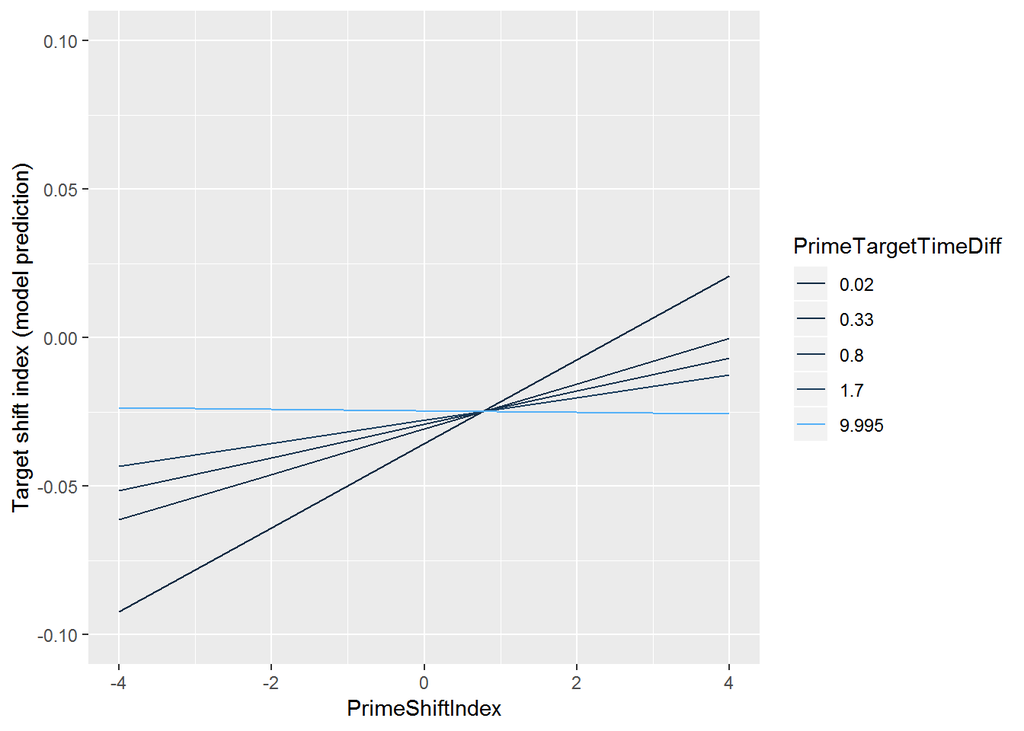

```r
primingMod %>%
  Effect(c("PrimeShiftIndex", "PrimeTargetTimeDiff"),
         .,
         xlevels=list(PrimeTargetTimeDiff = primingVowels$PrimeTargetTimeDiff %>% quantile(0:4/4))) %>%
  df.eff() %>%
  ggplot(aes(x=PrimeShiftIndex, y=fit, group=PrimeTargetTimeDiff, color=PrimeTargetTimeDiff)) +
  geom_line() +
  scale_y_continuous(ylabel, limits=c(-0.1, 0.1)) +
  scale_color_continuous(guide="legend", labels=brks %>% round(3), breaks=brks)
```

Finally, the colors for the first 4 lines are indistinguishable, thanks to the fact that the numbers themselves are bunched so closely together and `ggplot2` maps this numerical gradient to a color gradient via a linear mapping; this is why the lines for 2.5, 5.0, 7.5, and 10 had nicely-spaced-out hues in the earlier plot. To make these colors easier to tell apart, we can pass a `trans="log"` argument to `scale_color_continuous`, which maps the `PrimeTargetTimeDiff` to a color gradient via a log mapping rather than a linear mapping. We also pass `brks + .Machine$double.eps` to the `breaks` argument, because otherwise the line for 0.02 goes away.

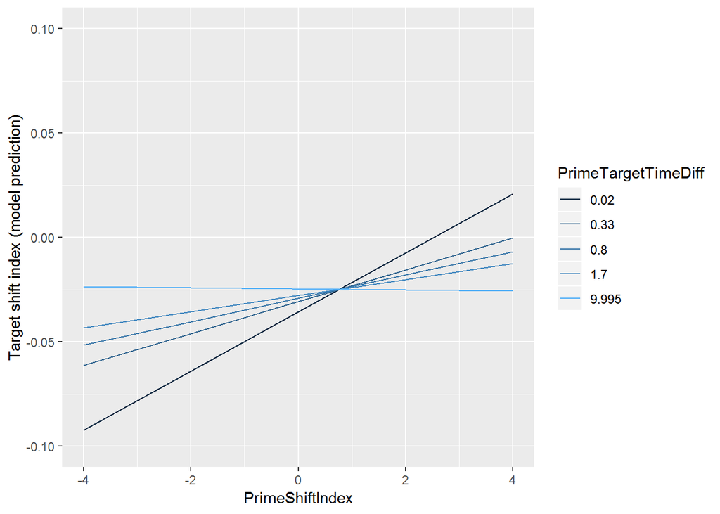

```r
primingMod %>%
  Effect(c("PrimeShiftIndex", "PrimeTargetTimeDiff"),
         .,
         xlevels=list(PrimeTargetTimeDiff = primingVowels$PrimeTargetTimeDiff %>% quantile(0:4/4))) %>%
  df.eff() %>%
  ggplot(aes(x=PrimeShiftIndex, y=fit, group=PrimeTargetTimeDiff, color=PrimeTargetTimeDiff)) +
  geom_line() +
  scale_y_continuous(ylabel, limits=c(-0.1, 0.1)) +
  scale_color_continuous(guide="legend", labels=brks %>% round(3),
                         breaks=brks + .Machine$double.eps, trans="log")
```

There you have it. This plot effectively conveys the finding that a longer delay between prime and target lessens the potency of the repetition effect, while remaining faithful to both the visual language we’ve built up across plots (if `PrimeShiftIndex` is in a plot, it always gets mapped to the `x` aesthetic) and the shape of the data (by not distorting the distribution of `PrimeTargetTimeDiff`).

## 4.5 A four-way interaction?!?!

Yes, you can even plot four-way interactions that make sense! In our model, a lot of the lower-order effects are mediated by the interaction of the Target and Prime vowel categories—and this includes the interaction of `PrimeShiftIndex` and `PrimeTargetTimeDiff` that we just plotted. You can turn the previous plot into a four-way interaction plot by minimally changing the code (all I’ve changed is adding `Prime` and `Target` to the `Effect()` call, adding a `facet_grid()` call, and changing the `limits` in `scale_y_continuous()`):

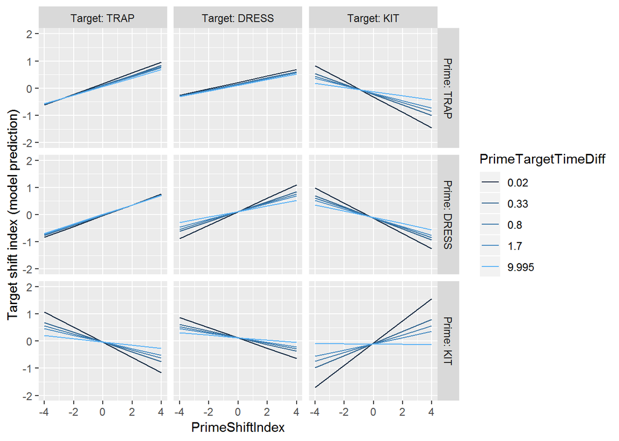

```r
primingMod %>%
  Effect(c("PrimeShiftIndex", "Prime", "Target", "PrimeTargetTimeDiff"),
         .,
         xlevels=list(PrimeTargetTimeDiff = primingVowels$PrimeTargetTimeDiff %>% quantile(0:4/4))) %>%
  df.eff() %>%
  ggplot(aes(x=PrimeShiftIndex, y=fit, group=PrimeTargetTimeDiff, color=PrimeTargetTimeDiff)) +
  geom_line() +
  facet_grid(Prime ~ Target, labeller=label_both) +
  scale_y_continuous(ylabel, limits=c(-2, 2)) +
  scale_color_continuous(guide="legend", labels=brks %>% round(3),
                         breaks=brks + .Machine$double.eps, trans="log")
```

# 5 What about glmer?

The `effects` package works for mixed-effects models of binary response data run with `glmer()` too! And actually, it works for lots of different models:

```r
methods(Effect)
```

```
 [1] Effect.betareg  Effect.clm      Effect.clm2     Effect.clmm
 [5] Effect.default  Effect.gls      Effect.lm       Effect.lme
 [9] Effect.merMod   Effect.mlm      Effect.multinom Effect.poLCA
[13] Effect.polr     Effect.rlmerMod Effect.svyglm
see '?methods' for accessing help and source code
```

With `glmer()`, the syntax is the same. Let’s say we want to run a model predicting the likelihood of DRESS (as opposed to TRAP) given the vowel’s duration:

```r
dummyGlmer <- glmer(Target ~ TargetVowelDur + (1|Speaker),
                  primingVowels %>%
                    filter(!is.na(AgeGroup)) %>%
                    filter(Target %in% c("DRESS", "TRAP")) %>%
                    droplevels(),
                  family="binomial")
dummyGlmer %>% summary()
```

```
Generalized linear mixed model fit by maximum likelihood (Laplace
  Approximation) [glmerMod]
 Family: binomial  ( logit )
Formula: Target ~ TargetVowelDur + (1 | Speaker)
   Data:
primingVowels %>% filter(!is.na(AgeGroup)) %>% filter(Target %in%
    c("DRESS", "TRAP")) %>% droplevels()

     AIC      BIC   logLik deviance df.resid
 38828.4  38853.3 -19411.2  38822.4    30361

Scaled residuals:
    Min      1Q  Median      3Q     Max
-1.7451 -0.9409 -0.3503  0.9104 14.2784

Random effects:
 Groups  Name        Variance Std.Dev.
 Speaker (Intercept) 0.06602  0.2569
Number of obs: 30364, groups:  Speaker, 146

Fixed effects:
               Estimate Std. Error z value Pr(>|z|)
(Intercept)      0.9143     0.0328   27.88   <2e-16 ***
TargetVowelDur -10.9878     0.2360  -46.56   <2e-16 ***
---
Signif. codes:  0 '***' 0.001 '**' 0.01 '*' 0.05 '.' 0.1 ' ' 1

Correlation of Fixed Effects:
            (Intr)
TargetVwlDr -0.632
```

We pipe this model to `Effect()`, then to `df.eff()`, then to `ggplot()` the same way we did with `lmer()`s.

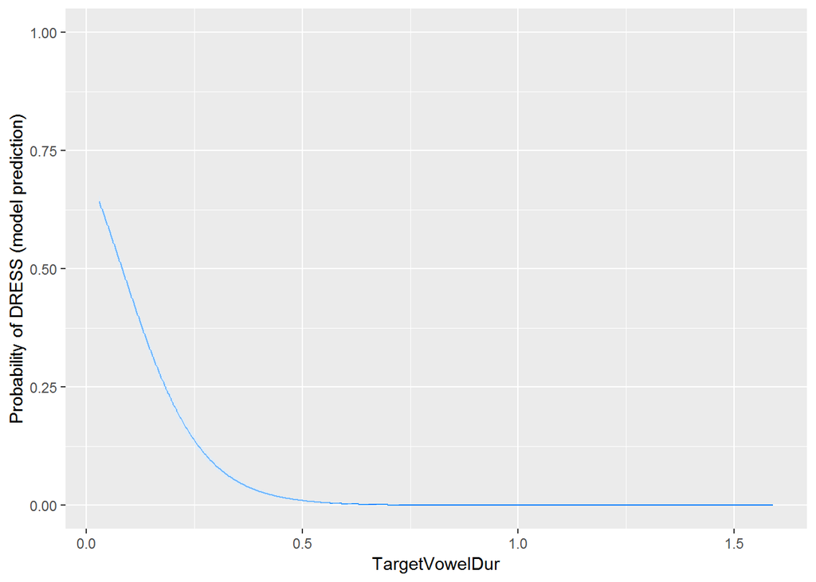

```r
dummyGlmer %>%
  Effect(c("TargetVowelDur"), ., xlevels=list(TargetVowelDur=1000)) %>%
  df.eff() %>%
  ggplot(aes(x=TargetVowelDur, y=fit, ymin=lower, ymax=upper)) +
  geom_line(color=lineCol) +
  geom_ribbon(fill=ribbonFill, alpha=ribbonAlpha) +
  scale_y_continuous("Probability of DRESS (model prediction)", limits=c(0, 1))
```

Note that `effects` automatically back-transforms the model’s effects (which are reported in the summary in log-odds) into [0, 1] probability space.

# 6 Conclusion

In conclusion, putting together effects plots that are easy to understand can be time-consuming, but I think it’s an indispensable part of analyzing your data and communicating your findings. So while perfecting these plots is an art, hopefully with this guide you’ll at least avoid any issues in implementing your vision!